# 🎓 Master of Science in Applied Data Science 🎓

## 🤖 Machine Learning and Predictive Analytics 🤖

## 📅 Week 1: What Do Machines Learn? 📅

## Instructions 📢

- **Purpose:** This assignment introduces you to core machine learning concepts and their practical application. You'll work hands-on with a dataset, apply ML techniques, and interpret your findings.
- **Prerequisites:**
  - Familiarity with Python and libraries such as NumPy, Pandas, and Matplotlib.
  - A solid understanding of the concepts covered in Week 1: "What Do Machines Learn?"
- **How to Complete:**
  - Work through each question in the assignment thoroughly.
  - Complete all the indicated sub-parts within each question.
  - Pay attention to the point values assigned to different parts. These indicate the relative weight to allocate to your solutions and explanations.

**Additional Tips:**

- **Collaboration Encouraged:** Feel free to discuss concepts and questions with your peers (but submit your own independent work). 🤝
- **Experiment and Explore:** Don't be afraid to experiment with the code and parameters. Learning happens by trying things out! 🧪
- **Ask for Help:** If you get stuck, reach out to your instructor or TA for guidance. 💡

## Question 1: Exploratory Data Analysis (40 points)

### **Part A: Data Loading and Summarization (10 points)**

**Instructions:**

1. **Import Libraries:** Begin by importing the essential data science libraries:

```python
import numpy as np
import pandas as pd
import matplotlib.pyplot as plt
```

2. **Load Your Dataset:** Load the dataset labeled `Week_1_Train.csv` into a Pandas DataFrame. Replace the placeholders with the correct file path and format based on how the data is stored (CSV, Excel, etc.) 💾

```python
# Example: Loading a CSV dataset
df = pd.read_csv('/Users/edwinhsu/Assignment/Machine Learning & Predictive Analytics/Week_1_Train-2.csv')
```

3. **Summarize the Data:** Get a sense of your data's structure and content 📊:

```python
# Inspect the shape
print("Shape of the dataset:", df.shape)
```

```
Shape of the dataset: (39073, 6)
```

```python
# View the first few rows
print("First few rows of the dataset:")
print(df.head())
```

```
First few rows of the dataset:
   age  capital-gain  capital-loss  hours-per-week  education-num  class
0   18           0.0           0.0              12              8  <=50K
1   29           0.0           0.0              38              9  <=50K
2   29           0.0           0.0              52             10  <=50K
3   49           0.0           0.0              85             13   >50K
4   38           0.0           0.0              50              9   >50K
```

```python
# Data types
print("Data types of each column:")
print(df.dtypes)
```

```
Data types of each column:
age                 int64
capital-gain      float64
capital-loss      float64
hours-per-week      int64
education-num       int64
class              object
dtype: object
```

```python
# Summary statistics
print("Summary statistics:")
print(df.describe())
```

```
Summary statistics:
                age  capital-gain  capital-loss  hours-per-week  education-num
count  39073.000000  39073.000000  39073.000000    39073.000000   39073.000000
mean      38.599135   1060.054948     87.142682       40.389092      10.074937
std       13.677527   7347.159048    403.678019       12.359776       2.569452
min       17.000000      0.000000      0.000000        1.000000       1.000000
25%       28.000000      0.000000      0.000000       40.000000       9.000000
50%       37.000000      0.000000      0.000000       40.000000      10.000000
75%       48.000000      0.000000      0.000000       45.000000      12.000000
max       90.000000  99999.000000   4356.000000       99.000000      16.000000
```

```python
# Missing values
print("Missing values:")
print(df.isnull().sum())
```

```
Missing values:
age               0
capital-gain      0
capital-loss      0
hours-per-week    0
education-num     0
class             0
dtype: int64
```

### **Part B: Visual Explorations (15 points)**

**Instructions:**

1. **Distribution Examination**: Create histograms to examine the distribution of each individual feature in your dataset. Use `Matplotlib` for this.

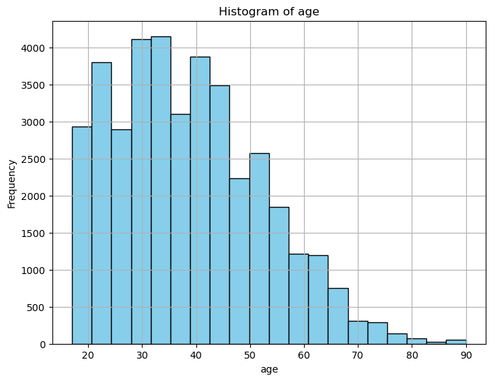

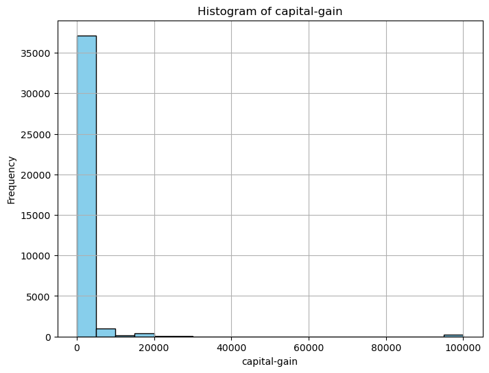

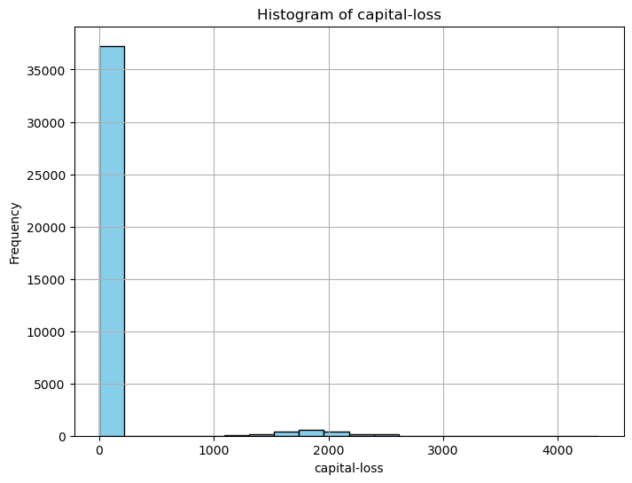

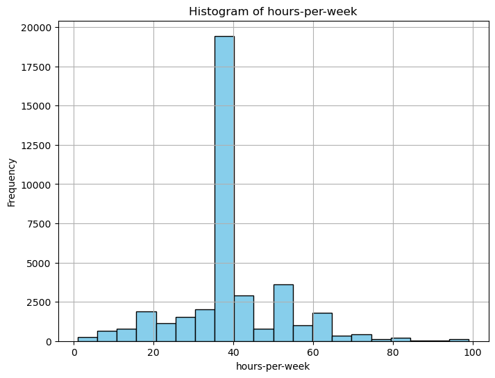

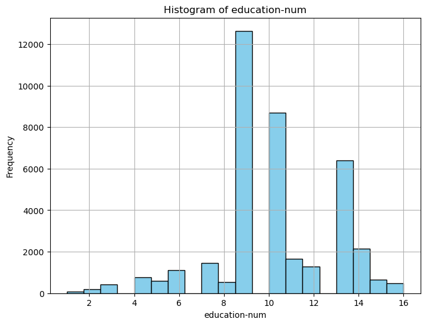

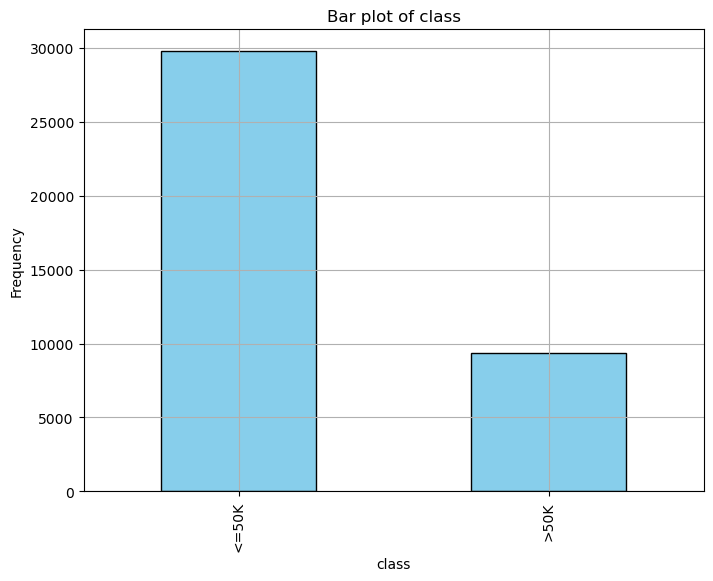

```python
# Loop through each column
for column in df.columns:
    if df[column].dtype in ['int64', 'float64']:
        # For numerical columns, create histograms
        plt.figure(figsize=(8, 6))
        plt.hist(df[column], bins=20, color='skyblue', edgecolor='black')
        plt.title(f'Histogram of {column}')
        plt.xlabel(column)
        plt.ylabel('Frequency')
        plt.grid(True)
        plt.show()
    else:
        # For categorical columns, create bar plots
        plt.figure(figsize=(8, 6))
        df[column].value_counts().plot(kind='bar', color='skyblue', edgecolor='black')
        plt.title(f'Bar plot of {column}')
        plt.xlabel(column)
        plt.ylabel('Frequency')
        plt.grid(True)
        plt.show()
```

2. **Comparison by `class`:** Create pairs of histograms to compare the distributions of key features between income classes ('>50K' and '<=50K'). Consider features like:
   - `age`
   - `education-num`
   - `hours-per-week`
   - `capital-gain`/`capital-loss` (these might be particularly insightful)

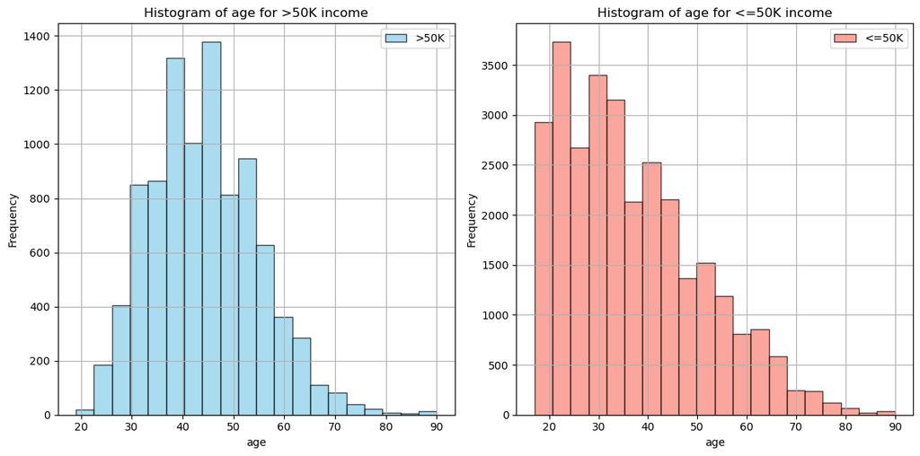

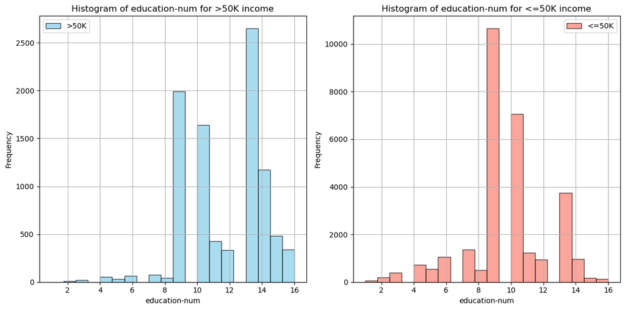

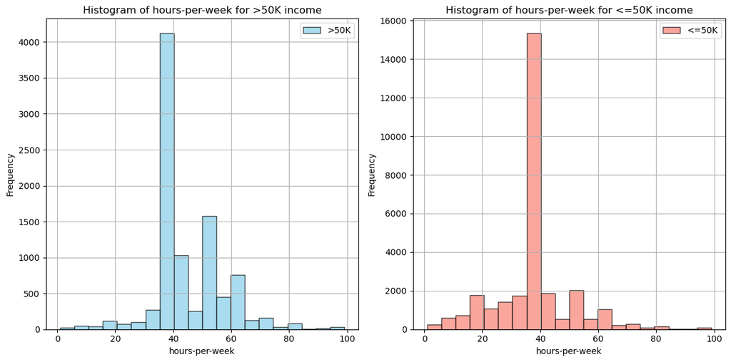

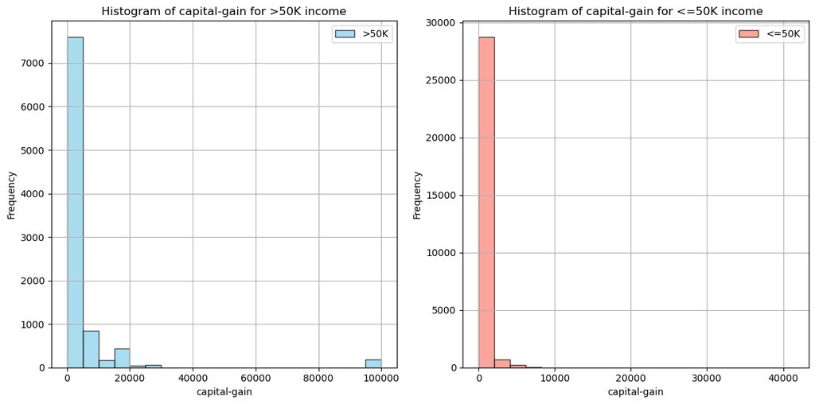

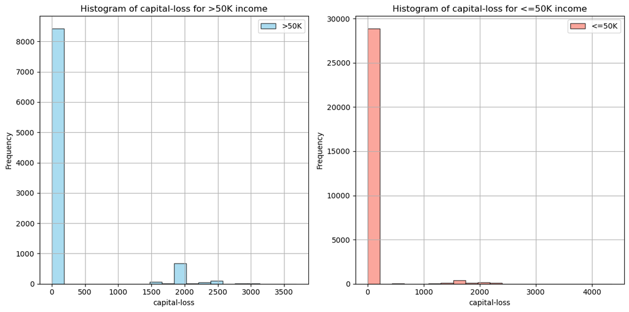

```python
# Define features of interest
features = ['age', 'education-num', 'hours-per-week', 'capital-gain', 'capital-loss']

# Iterate through features and create pairs of histograms
for feature in features:
    plt.figure(figsize=(12, 6))

    # Histogram for >50K income class
    plt.subplot(1, 2, 1)
    plt.hist(df[df['class'] == '>50K'][feature], bins=20, color='skyblue', edgecolor='black', alpha=0.7, label='>50K')
    plt.title(f'Histogram of {feature} for >50K income')
    plt.xlabel(feature)
    plt.ylabel('Frequency')
    plt.grid(True)
    plt.legend()

    # Histogram for <=50K income class
    plt.subplot(1, 2, 2)
    plt.hist(df[df['class'] == '<=50K'][feature], bins=20, color='salmon', edgecolor='black', alpha=0.7, label='<=50K')
    plt.title(f'Histogram of {feature} for <=50K income')
    plt.xlabel(feature)
    plt.ylabel('Frequency')
    plt.grid(True)
    plt.legend()

    plt.tight_layout()
    plt.show()
```

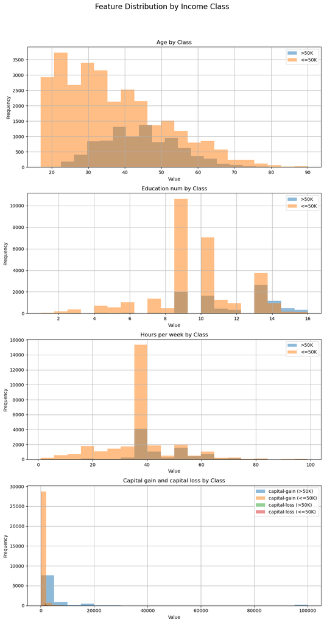

```python
# To compare the distributions of key features between the two income classes,
# we'll also create pairs of histograms for each of the mentioned features.

fig, axes = plt.subplots(nrows=4, ncols=1, figsize=(10, 20))
fig.suptitle('Feature Distribution by Income Class', fontsize=16)

# Features to compare
features_to_compare = ['age', 'education-num', 'hours-per-week', ['capital-gain', 'capital-loss']]

# Iterate over the features and plot the histograms for each class
for ax, feature in zip(axes, features_to_compare):
    if isinstance(feature, list):  # For capital-gain and capital-loss
        for f in feature:
            df[df['class'] == '>50K'][f].hist(ax=ax, bins=20, alpha=0.5, label=f'{f} (>50K)')
            df[df['class'] == '<=50K'][f].hist(ax=ax, bins=20, alpha=0.5, label=f'{f} (<=50K)')
        ax.set_title(' and '.join(feature).replace('-', ' ').capitalize() + ' by Class')
    else:
        df[df['class'] == '>50K'][feature].hist(ax=ax, bins=20, alpha=0.5, label='>50K')
        df[df['class'] == '<=50K'][feature].hist(ax=ax, bins=20, alpha=0.5, label='<=50K')
        ax.set_title(feature.replace('-', ' ').capitalize() + ' by Class')

    ax.legend()
    ax.set_xlabel('Value')
    ax.set_ylabel('Frequency')

plt.tight_layout(rect=[0, 0.03, 1, 0.95])
plt.show()
```

### **Part C: Insights and Data Preprocessing (15 points)**

**Observations and Preprocessing:**

1. **Distribution Insights:**
   - **Age & Hours-per-week:** How might the shapes of the "age" and "hours-per-week" distributions relate to typical working patterns? Are the outliers likely to be data errors or representative of real situations?
   - **Education:** What might explain the two major peaks in the "education-num" distribution? Could this feature be made more informative (e.g., by grouping or mapping values)?
   - **Income Class Differences:** Which features seem to show the most significant differences in distribution between the '>50K' and '<=50K' income classes?

# ✍️ Respond to the question in this markdown cell ✍️

- **Age:** The age distribution typically reflects the working-age population, with a probable peak in the mid-range ages (e.g., 20-50 years), indicating the majority of the workforce. The presence of younger and older age groups might be less prominent but significant, representing part-time or reduced hours work often taken by students and retirees. Outliers, such as very young or very old workers, while less common, could represent real situations rather than data errors. Young outliers might be young professionals or those in specific industries like technology or entertainment, whereas older outliers could be individuals in roles that don't require physical labor, consulting positions, or those delaying retirement.
- **Hours-per-week Distribution:** This distribution likely has a significant peak around the standard 40-hour workweek, reflecting full-time employment norms. Variations with fewer hours can indicate part-time work, while more than 40 hours may reflect overtime work, second jobs, or industries with longer working hours (e.g., healthcare, startups, or law). Outliers with extremely high or low hours are possibly real but could be influenced by reporting errors, unpaid overtime not accounted for, or unique employment situations.
- **Education-num Distribution:** The two major peaks in this distribution might correspond to significant educational milestones, such as high school graduation and the completion of a bachelor's degree. These peaks are indicative of the educational qualifications most commonly held in the workforce. Making this feature more informative could involve mapping these numerical values to more descriptive categories that reflect these milestones (e.g., 'High School', 'Bachelor's Degree', 'Master's Degree', etc.) or grouping similar education levels to reduce granularity and highlight the general education level's impact on income.
- **Income Class Differences:**
1. Capital Gain and Loss. These features likely show significant differences between the two income classes. Higher capital gains can be associated with higher income, as they might indicate more substantial investments or assets. Conversely, lower income individuals might have fewer opportunities to invest, resulting in lower capital gains.
2. Education. The education-num feature also likely shows a significant difference in distribution between income classes. Higher education levels are often correlated with higher income due to the association between specialized skills or qualifications and better-paying jobs.
3. Age and Hours-per-week: Age might show a subtle difference as it correlates with experience, and thus potential income, while hours-per-week could reflect the type of employment (part-time vs. full-time) and overtime work, which also impacts income.

In summary, **capital gain/loss** and **education level** seem to exhibit the **most** notable differences in distribution between the two income classes, reflecting the direct influence of investment capacity and educational attainment on earning potential. Age and hours-per-week also present interesting patterns that correlate with income but might be influenced by broader socio-economic factors and personal choices.

2. **Preprocessing Considerations:**
   - **Outliers:** Should any potential outliers (identified in Part B) be removed or treated differently? Justify your decisions.
   - **Missing Data:** (If applicable) Did you find any missing data? How might you handle it?

# ✍️ Respond to the question in this markdown cell ✍️

- **Outliers:** When considering outliers identified in the distributions of "age" and "hours-per-week," the decision to remove or treat them differently depends on several factors, including the goal of the analysis. If the analysis aims to understand general working patterns or develop models for the majority workforce, extreme age outliers might skew results and could be excluded or treated separately. However, if the goal includes studying the full spectrum of the workforce, including unique employment situations, these outliers should be retained. Similarly, extremely high or low working hours might reflect unique job types, multiple job holdings, or specific industries with unusual hours, the decision to remove or adjust these data points should be based on the analysis's objectives. Assuming this is for study focused on labor market diversity, keeping these outliers could highlight critical aspects of work-life balance and employment practices.
- **Missing Data:** Based on the initial examination, there was no missing data in the numerical features reviewed.

## Question 2: Model Building and Evaluation (35 points)

### **Part A: Model Selection and Training (10 points)**

**Instructions:**

1. **Library:** Import the necessary Scikit-learn components. Start with a nonparametric model K-Nearest Neighbors (KNN)

```python
from sklearn.neighbors import KNeighborsClassifier
from sklearn.model_selection import train_test_split
from sklearn.metrics import accuracy_score
```

2. **Dataset Preparation:** Assuming your data is in a DataFrame named 'df' with the target in column `class`

```python
from sklearn.preprocessing import LabelEncoder
# Encode the categorical target variable ('class') into a numeric format
encoder = LabelEncoder()
df['class_encoded'] = encoder.fit_transform(df['class'])
```

3. **Train/Test Split:** Split your data into `X_train`, `X_test`, `y_train`, and `y_test`

```python
# Prepare the features (X) and target (y)
X = df.drop(columns=['class', 'class_encoded'])  # Exclude the target column and encoded target from features
y = df['class_encoded']  # Use the encoded target variable

# 20% of the data used for testing
X_train, X_test, y_train, y_test = train_test_split(X, y, test_size=0.2, random_state=42)
```

4. **Instantiate:** Create a KNN classifier instance. Set an initial 'n_neighbors' value (e.g., 5).

```python
# Initialize and fit the KNN model
knn = KNeighborsClassifier(n_neighbors=5)  # Using 5 neighbors for KNN
```

5. **Fitting:** Train the model on the training data.

```python
knn.fit(X_train, y_train)
```

```
KNeighborsClassifier()
```

### **Part B: Performance Evaluation (15 points)**

**Instructions:**

1. **Predictions:** Generate predictions on the test set.

```python
# Make predictions and evaluate the model
y_pred = knn.predict(X_test)
```

2. **Accuracy:** Calculate accuracy as the primary metric.

```python
accuracy = accuracy_score(y_test, y_pred)
accuracy
```

```
0.8220089571337172
```

### **Part C: Bias-Variance Analysis (10 points)**

1. **Experimentation:**
   - Create a loop to retrain the KNN model with different 'n_neighbors' values (e.g., 1, 5, 10, 15, 20, 25, 30).
   - Store and print the training and test accuracies for each.
   - Plot training and test accuracy versus complexity.

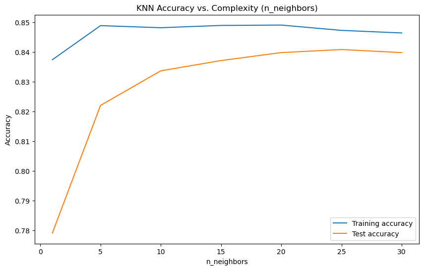

```
n_neighbors: 1, Training Acc: 0.8374, Test Acc: 0.7790
n_neighbors: 5, Training Acc: 0.8489, Test Acc: 0.8220
n_neighbors: 10, Training Acc: 0.8482, Test Acc: 0.8337
n_neighbors: 15, Training Acc: 0.8489, Test Acc: 0.8371
n_neighbors: 20, Training Acc: 0.8491, Test Acc: 0.8398
n_neighbors: 25, Training Acc: 0.8473, Test Acc: 0.8408
n_neighbors: 30, Training Acc: 0.8464, Test Acc: 0.8398
```

```python
# Values of n_neighbors to experiment with
neighbors_settings = [1, 5, 10, 15, 20, 25, 30]

# Lists to store the accuracies
training_accuracy = []
test_accuracy = []

# Loop over different values of n_neighbors
for n_neighbors in neighbors_settings:
    # Build the model
    clf = KNeighborsClassifier(n_neighbors=n_neighbors)
    clf.fit(X_train, y_train)

    # Record training set accuracy
    training_accuracy.append(clf.score(X_train, y_train))
    # Record test set accuracy
    test_accuracy.append(clf.score(X_test, y_test))

# Plotting the results
plt.figure(figsize=(10, 6))
plt.plot(neighbors_settings, training_accuracy, label="Training accuracy")
plt.plot(neighbors_settings, test_accuracy, label="Test accuracy")
plt.ylabel("Accuracy")
plt.xlabel("n_neighbors")
plt.legend()
plt.title("KNN Accuracy vs. Complexity (n_neighbors)")
plt.show()

# Print the accuracies for each n_neighbors
for n, train_acc, test_acc in zip(neighbors_settings, training_accuracy, test_accuracy):
    print(f"n_neighbors: {n}, Training Acc: {train_acc:.4f}, Test Acc: {test_acc:.4f}")
```

2. **Observation:**
   - How does changing the number of neighbors affect performance on both the training and test sets?
   - Relate your observations to the concepts of overfitting and underfitting.

# ✍️ Respond to the question in this markdown cell ✍️

**As n_neighbors increases (5, 10, 15, 20, 25, 30)**, the training accuracy shows a slight increase and then a gradual decrease, suggesting the model becomes less tailored to the training data's specific characteristics and more general. The test accuracy improves as n_neighbors increases from 5 to 25, indicating better generalization up to a point. This is because the model is relying on a larger pool of neighbors for the classification, smoothing out the noise and idiosyncrasies of the training data.

**From n_neighbors = 25 to n_neighbors = 30**, both the training and test accuracies slightly decrease when n_neighbors is increased from 25 to 30, which may suggest the onset of underfitting. This means the model is starting to become too simple and losing its ability to capture the underlying pattern in the data, indicated by a decrease in performance on both the training and test sets.

**Overfitting vs. Underfitting:** The best model balance is achieved with n_neighbors around 25, as it gives the highest test accuracy while maintaining a comparable training accuracy. This balance is key to achieving good generalization without overfitting or underfitting.

# Question 3: Hyperparameter Exploration and Refinement (25 points)

### **Part A: Hyperparameter Impact (10 points)**

1. **Hyperparameter Focus:** We'll investigate the 'metric' hyperparameter, which determines the distance calculation used by KNN. Briefly research these three different distance metrics (Minkowski, City Block, Euclidean) and their suitability for different data types.
2. **Experimentation:**
   - Create a list of the metrics to test.
   - Modify your loop from Question 2 to iterate over different 'metric' values instead of 'n_neighbors'.
   - Keep 'n_neighbors' fixed at 25.
   - Store training and test accuracies for each metric.
3. **Visualization:** Plot the accuracies against the different distance metrics tested.

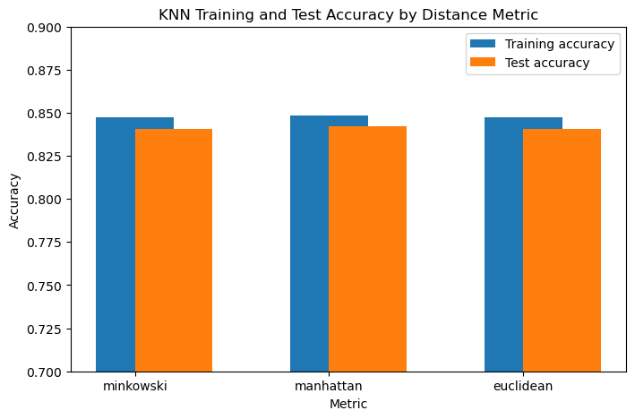

```
Metric: minkowski, Training Acc: 0.8473, Test Acc: 0.8408
Metric: manhattan, Training Acc: 0.8484, Test Acc: 0.8422
Metric: euclidean, Training Acc: 0.8473, Test Acc: 0.8408
```

```python
# Define the list of metrics to test
metrics = ['minkowski', 'manhattan', 'euclidean']

# Initialize the classifier with fixed n_neighbors
n_neighbors = 25

# Dictionaries to store the accuracies
training_accuracy_metrics = {}
test_accuracy_metrics = {}

# Loop over different metrics
for metric in metrics:
    # Build the model with the specified metric
    clf = KNeighborsClassifier(n_neighbors=n_neighbors, metric=metric)
    clf.fit(X_train, y_train)

    # Store the training and test accuracies with the metric as the key
    training_accuracy_metrics[metric] = clf.score(X_train, y_train)
    test_accuracy_metrics[metric] = clf.score(X_test, y_test)

# Visualization
plt.figure(figsize=(8, 5))
plt.bar(training_accuracy_metrics.keys(), training_accuracy_metrics.values(), width=0.4, label="Training accuracy", align='center')
plt.bar(test_accuracy_metrics.keys(), test_accuracy_metrics.values(), width=0.4, label="Test accuracy", align='edge')
plt.xlabel("Metric")
plt.ylabel("Accuracy")
plt.ylim(0.7, 0.9)
plt.legend()
plt.title("KNN Training and Test Accuracy by Distance Metric")
plt.show()

# Print the accuracies for each metric
for metric in metrics:
    print(f"Metric: {metric}, Training Acc: {training_accuracy_metrics[metric]:.4f}, Test Acc: {test_accuracy_metrics[metric]:.4f}")
```

### **Part B: Analysis and Refinement (10 points)**

1. **Interpretation:**
   - Discuss how the chosen hyperparameter affects both training and test accuracy.
   - Does it influence the bias-variance tradeoff? Explain.
2. **Refinement:** Based on your observations, can you identify a combination of hyperparameter values that might improve your model's performance compared to the initial settings?

# ✍️ Respond to the question in this markdown cell ✍️

The provided accuracies for the KNN model with n_neighbors fixed at 25 show minimal variation in performance across the different distance metrics. The Minkowski and Euclidean metrics yielded identical accuracies, which is expected because the Euclidean distance is a special case of the Minkowski distance where the parameter p (which determines the power of the distance metric) is set to 2. The Manhattan distance (or city block distance) performed slightly better than the other two metrics.

The slight increase in test accuracy with the Manhattan metric suggests that the Manhattan distance might be slightly more appropriate for the data's geometry or distribution. It could be that the data has a structure that is more aligned with the grid-like movements (additive steps rather than the direct path) that Manhattan distance encapsulates

Changing the distance metric can influence the bias-variance tradeoff by altering the way distances are calculated and, therefore, the decision boundaries in the feature space. A metric that leads to better generalization (higher test accuracy) is reducing variance without significantly increasing bias.In this case, the Manhattan distance has the highest test accuracy, suggesting that it may offer a better tradeoff between bias and variance for this particular dataset.

To refine the KNN model based on the provided observations, we can consider two facets:

**Distance Metric:** The Manhattan metric yields a slightly higher test accuracy. Therefore, we should use 'manhattan' for the metric hyperparameter. **Number of Neighbors:** since the highest test accuracy is achieved at n_neighbors = 25, this seems to be a suitable value to keep. n_neighbors: 25

### **Part C: Takeaways (5 points)**

- Summarize the key insights you gained in this assignment about hyperparameter tuning, the bias-variance tradeoff, and its importance in refining machine learning models.

# ✍️ Respond to the question in this markdown cell ✍️

Through this assignment on hyperparameter tuning and exploring the bias-variance tradeoff, several key insights are as follows:

Hyperparameter Tuning is critical. Adjusting hyperparameters such as n_neighbors and metric in a KNN classifier significantly impacts model performance. This process of tuning allows us to refine our model to better fit the data without overfitting or underfitting, optimizing its ability to generalize to unseen data.

Understanding the Bias-Variance tradeoff is needed. This concept is central to machine learning and critical in choosing the right model complexity. A model with high bias (underfitting) oversimplifies the problem, failing to capture underlying patterns, while a model with high variance (overfitting) captures noise as if it were signal, performing poorly on new data. The goal is to find a **sweet spot** where both bias and variance are minimized to improve model performance.

Importance of distance metrics in KNN. The choice of distance metric (e.g., Minkowski, Euclidean, Manhattan) can affect how well the KNN model performs, as it changes how the similarity between data points is calculated. This choice can influence the bias-variance balance and, consequently, the model's effectiveness.

Role of n_neighbors can control model complexity. The number of neighbors, n_neighbors, directly influences the complexity of the KNN model. A lower n_neighbors value can lead to overfitting (high variance), while a higher value can cause underfitting (high bias). Properly selecting this parameter is crucial for achieving the best model performance.

Iterative process of model improvement. As mentioned in the lecture videos, refining a machine learning model is an iterative process involving experimentation with different hyperparameter settings, model structures, and preprocessing steps. Continuous evaluation and adjustment based on performance metrics are essential to developing an effective model. Through experimentation, it was observed that there are **no one-size-fits-all** settings for hyperparameters (referred as No Free Lunch (NFL) theorem). Instead, hyperparameter values need to be tailored to the specific dataset and problem. Techniques such as cross-validation can be invaluable in identifying the most effective settings.